# R_Assignment

Ann Murithi

3/11/2022

Load all the packages required for this work

Load the two files to be used

#PART 1

#DATA INSPECTION ##Fang_et_al_genotypes.txt Check for 1. Data type 2. the class 3. Head and tail 4. Data dimension 5. Number of rows and colums 6. Data structure 7. using view to see the data table

```
## [1] TRUE
```

```
## [1] FALSE
```

```
## [1] "list"
```

```
##   Sample_ID   JG_OTU Group abph1.20 abph1.22 ae1.3 ae1.4 ae1.5 an1.4 ba1.6
## 1     SL-15 T-aust-1 TRIPS      ?/?      ?/?   T/T   G/G   T/T   C/C   ?/?
## 2     SL-16 T-aust-2 TRIPS      ?/?      ?/?   T/T   ?/?   T/T   C/C   A/G
## 3     SL-11 T-brav-1 TRIPS      ?/?      ?/?   T/T   G/G   T/T   ?/?   G/G
## 4     SL-12 T-brav-2 TRIPS      ?/?      ?/?   T/T   G/G   T/T   C/C   G/G
## 5     SL-18   T-cund TRIPS      ?/?      ?/?   T/T   G/G   T/T   C/C   ?/?
## 6      SL-2 T-dact-1 TRIPS      ?/?      ?/?   T/T   G/G   T/T   C/C   A/G
##   ba1.9 bt2.5 bt2.7 bt2.8 Fea2.1 Fea2.5 id1.3 lg2.11 lg2.2 pbf1.1 pbf1.2 pbf1.3
## 1   G/G   ?/?   A/A   ?/?    C/C    A/A   T/T    C/C   A/A    ?/?    ?/?    ?/?
## 2   G/G   ?/?   A/A   ?/?    C/C    A/A   T/T    C/C   A/A    T/T    ?/?    ?/?
## 3   G/G   C/C   A/A   ?/?    ?/?    A/A   T/T    C/C   A/A    T/T    ?/?    ?/?
## 4   G/G   C/C   A/A   ?/?    ?/?    A/A   T/T    C/C   A/A    T/T    ?/?    ?/?
## 5   G/G   ?/?   A/A   ?/?    C/C    A/A   T/T    C/C   A/A    T/T    ?/?    ?/?
## 6   G/G   ?/?   A/A   ?/?    C/C    A/A   T/T    C/C   A/A    T/T    ?/?    ?/?
##   pbf1.5 pbf1.6 pbf1.7 pbf1.8 PZA00003.11 PZA00004.2 PZA00005.8 PZA00005.9
```

[output cut: 1021 more lines]

```
##      Sample_ID             JG_OTU Group abph1.20 abph1.22 ae1.3 ae1.4 ae1.5
## 2777    SYN262 Zmm-IL-W22-Rrstd_v ZMMIL      C/C      A/A   T/T   G/G   C/C
## 2778     S0398      Zmm-IL-W64A_a ZMMIL      G/G      A/A   T/T   G/G   C/C
## 2779     S1636    Zmm-IL-W64A_b_s ZMMIL      G/G      A/A   T/T   G/G   C/C
## 2780    CU0201        Zmm-IL-WD_f ZMMIL      C/C      A/A   T/T   G/G   C/C
## 2781     S0215         Zmm-IL-Wf9 ZMMIL      G/G      A/A   T/T   ?/?   C/C
## 2782    CU0202  Zmm-IL-Yu796_NS_f ZMMIL      C/C      A/A   T/T   G/G   C/C
##      an1.4 ba1.6 ba1.9 bt2.5 bt2.7 bt2.8 Fea2.1 Fea2.5 id1.3 lg2.11 lg2.2
## 2777   C/C   G/G   G/G   C/C   A/A   A/A    C/C    A/A   C/C    C/C   G/G
## 2778   C/C   G/G   G/G   C/C   G/G   A/A    ?/?    A/A   C/C    C/C   A/A
## 2779   C/C   G/G   G/G   C/C   G/G   A/A    G/G    A/A   C/C    C/C   A/A
## 2780   C/C   G/G   G/G   C/C   G/G   A/A    G/G    ?/?   C/C    C/C   G/G
## 2781   C/C   G/G   G/G   C/C   G/G   A/A    G/G    A/A   C/C    C/C   A/A
## 2782   C/C   ?/?   G/G   C/C   G/G   A/A    G/G    ?/?   ?/?    C/C   G/G
##      pbf1.1 pbf1.2 pbf1.3 pbf1.5 pbf1.6 pbf1.7 pbf1.8 PZA00003.11 PZA00004.2
```

[output cut: 1119 more lines]

```
## [1] 2782  986
```

```
## [1] 2782
```

```
## [1] 986
```

```
## 'data.frame':    2782 obs. of  986 variables:
##  $ Sample_ID     : chr  "SL-15" "SL-16" "SL-11" "SL-12" ...
##  $ JG_OTU        : chr  "T-aust-1" "T-aust-2" "T-brav-1" "T-brav-2" ...
##  $ Group         : chr  "TRIPS" "TRIPS" "TRIPS" "TRIPS" ...
##  $ abph1.20      : chr  "?/?" "?/?" "?/?" "?/?" ...
##  $ abph1.22      : chr  "?/?" "?/?" "?/?" "?/?" ...
##  $ ae1.3         : chr  "T/T" "T/T" "T/T" "T/T" ...
##  $ ae1.4         : chr  "G/G" "?/?" "G/G" "G/G" ...
##  $ ae1.5         : chr  "T/T" "T/T" "T/T" "T/T" ...
##  $ an1.4         : chr  "C/C" "C/C" "?/?" "C/C" ...
##  $ ba1.6         : chr  "?/?" "A/G" "G/G" "G/G" ...
##  $ ba1.9         : chr  "G/G" "G/G" "G/G" "G/G" ...
##  $ bt2.5         : chr  "?/?" "?/?" "C/C" "C/C" ...
##  $ bt2.7         : chr  "A/A" "A/A" "A/A" "A/A" ...
##  $ bt2.8         : chr  "?/?" "?/?" "?/?" "?/?" ...
```

[output cut: 86 more lines]

```
##   [1] "Sample_ID"      "JG_OTU"         "Group"          "abph1.20"
##   [5] "abph1.22"       "ae1.3"          "ae1.4"          "ae1.5"
##   [9] "an1.4"          "ba1.6"          "ba1.9"          "bt2.5"
##  [13] "bt2.7"          "bt2.8"          "Fea2.1"         "Fea2.5"
##  [17] "id1.3"          "lg2.11"         "lg2.2"          "pbf1.1"
##  [21] "pbf1.2"         "pbf1.3"         "pbf1.5"         "pbf1.6"
##  [25] "pbf1.7"         "pbf1.8"         "PZA00003.11"    "PZA00004.2"
##  [29] "PZA00005.8"     "PZA00005.9"     "PZA00006.13"    "PZA00006.14"
##  [33] "PZA00008.1"     "PZA00010.5"     "PZA00013.10"    "PZA00013.11"
##  [37] "PZA00013.9"     "PZA00015.4"     "PZA00017.1"     "PZA00018.5"
##  [41] "PZA00029.11"    "PZA00029.12"    "PZA00030.11"    "PZA00031.5"
##  [45] "PZA00041.3"     "PZA00042.2"     "PZA00042.5"     "PZA00043.7"
##  [49] "PZA00045.1"     "PZA00047.2"     "PZA00049.12"    "PZA00050.9"
##  [53] "PZA00051.2"     "PZA00058.5"     "PZA00058.6"     "PZA00060.2"
##  [57] "PZA00061.1"     "PZA00065.2"     "PZA00069.4"     "PZA00070.5"
```

[output cut: 232 more lines]

[output not shown]

[output cut: 341 more lines]

[output not shown]

##Snp_positions.txt Check for 1. Data type 2. the class 3. Head and tail 4. Data dimension 5. Number of rows and colums 6. Data structure 7. using view to see the data table

```
## [1] TRUE
```

```
## [1] FALSE
```

```
## [1] "list"
```

```
##     SNP_ID cdv_marker_id Chromosome  Position alt_pos mult_positions amplicon
## 1 abph1.20          5976          2  27403404                           abph1
## 2 abph1.22          5978          2  27403892                           abph1
## 3    ae1.3          6605          5 167889790                             ae1
## 4    ae1.4          6606          5 167889682                             ae1
## 5    ae1.5          6607          5 167889821                             ae1
## 6    an1.4          5982          1 240498509                             an1
##   cdv_map_feature.name  gene candidate.random Genaissance_daa_id
## 1             AB042260 abph1        candidate               8393
## 2             AB042260 abph1        candidate               8394
## 3                  ae1   ae1        candidate               8395
## 4                  ae1   ae1        candidate               8396
## 5                  ae1   ae1        candidate               8397
## 6                  an1   an1        candidate               8398
##   Sequenom_daa_id count_amplicons count_cmf count_gene
## 1           10474               1         1          1
## 2           10475               0         0          0
## 3           10477               1         1          1
## 4           10478               0         0          0
## 5           10479               0         0          0
## 6           10481               1         1          1
```

```
##     SNP_ID cdv_marker_id Chromosome  Position alt_pos mult_positions amplicon
## 978 zap1.2          3514          2 233128584                            zap1
## 979 zen1.1          3519    unknown   unknown                            zen1
## 980 zen1.2          3520    unknown   unknown                            zen1
## 981 zen1.4          3521    unknown   unknown                            zen1
## 982 zfl2.6          6463          2  12543294                            zfl2
## 983 zmm3.4          3527          9  16966348                            zmm3
##     cdv_map_feature.name gene candidate.random Genaissance_daa_id
## 978               L46400 zap1        candidate               8434
## 979             CF649098 zen1        candidate               8435
## 980             CF649098 zen1        candidate               8436
## 981             CF649098 zen1        candidate               8437
## 982                 zfl2 zfl2        candidate               8438
## 983               Y09301 zmm3        candidate              10104
##     Sequenom_daa_id count_amplicons count_cmf count_gene
## 978           11823               1         0          1
## 979           11824               1         1          1
## 980           11826               0         0          0
## 981           11827               0         0          0
## 982           11828               1         1          1
## 983           11829               1         0          1
```

```
## [1] 983  15
```

```
## [1] 983
```

```
## [1] 15
```

```
## 'data.frame':    983 obs. of  15 variables:
##  $ SNP_ID              : chr  "abph1.20" "abph1.22" "ae1.3" "ae1.4" ...
##  $ cdv_marker_id       : int  5976 5978 6605 6606 6607 5982 3463 3466 5983 5985 ...
##  $ Chromosome          : chr  "2" "2" "5" "5" ...
##  $ Position            : chr  "27403404" "27403892" "167889790" "167889682" ...
##  $ alt_pos             : chr  "" "" "" "" ...
##  $ mult_positions      : chr  "" "" "" "" ...
##  $ amplicon            : chr  "abph1" "abph1" "ae1" "ae1" ...
##  $ cdv_map_feature.name: chr  "AB042260" "AB042260" "ae1" "ae1" ...
##  $ gene                : chr  "abph1" "abph1" "ae1" "ae1" ...
##  $ candidate.random    : chr  "candidate" "candidate" "candidate" "candidate" ...
##  $ Genaissance_daa_id  : int  8393 8394 8395 8396 8397 8398 8399 8400 8401 8402 ...
##  $ Sequenom_daa_id     : int  10474 10475 10477 10478 10479 10481 10482 10483 10486 10487 ...
##  $ count_amplicons     : int  1 0 1 0 0 1 1 0 1 0 ...
##  $ count_cmf           : int  1 0 1 0 0 1 0 0 1 0 ...
##  $ count_gene          : int  1 0 1 0 0 1 1 0 1 0 ...
```

```
##  [1] "SNP_ID"               "cdv_marker_id"        "Chromosome"
##  [4] "Position"             "alt_pos"              "mult_positions"
##  [7] "amplicon"             "cdv_map_feature.name" "gene"
## [10] "candidate.random"     "Genaissance_daa_id"   "Sequenom_daa_id"
## [13] "count_amplicons"      "count_cmf"            "count_gene"
```

```
##               SNP_ID        cdv_marker_id           Chromosome
##          "character"            "integer"          "character"
##             Position              alt_pos       mult_positions
##          "character"          "character"          "character"
##             amplicon cdv_map_feature.name                 gene
##          "character"          "character"          "character"
##     candidate.random   Genaissance_daa_id      Sequenom_daa_id
##          "character"            "integer"            "integer"
##      count_amplicons            count_cmf           count_gene
##            "integer"            "integer"            "integer"
```

#DATA PROCESSING

##Snp_postion.txt

1. using snp_position.txt Create a new data frame by filtering SNP_ID, Chromosome and Position columns
2. Create an object called ‘new_snp’ containing the specifed columns
3. Quickly inspect the file by checking the number of columns and rows

```
## [1] 3
```

##Fang_et_al_genotype.txt

1. To create maize genotype
2. Filter third column “Group” using key words ZMMIL,ZMMLR and ZMMMR
3. Create an object called maize containg the filter
4. Quickly inspect the file by checking the number of columns and rows
5. repeat this step to create teosinte genotype files

```
## [1] 1573
```

```
## [1] 986
```

##Creating teosinte genotype file

```
## [1] 975
```

```
## [1] 986
```

##Transposing and Joining Here: 1. Transpose the maize genotype files and create a maize_transposed object 2. Change the Sample_ID to SNP_ID 3. Join the transposed object with new_snp object 4. The save new object maize.f 5. Repeat the new steps for teosinte and create a new object teosinte.f

```
##  [1] "2"        "5"        "1"        "3"        "4"        "6"
##  [7] "9"        "8"        "multiple" "7"        "unknown"  "10"
```

##Creating teosinte transposed and joined file

```
##  [1] "2"        "5"        "1"        "3"        "4"        "6"
##  [7] "9"        "8"        "multiple" "7"        "unknown"  "10"
```

##Extracting Chromosomes Here

#PART 2 #Visualization

##1.SNP Per Chromosome ###1a.Plotting SNP counts per chromosome_All Here: 1. Filter the original SNP file by position and specify less than inf 2. Pipe the filtering to create a bar graph of total counts of SNPs per chromosome 3. Give the X-axis and the y-axis a label

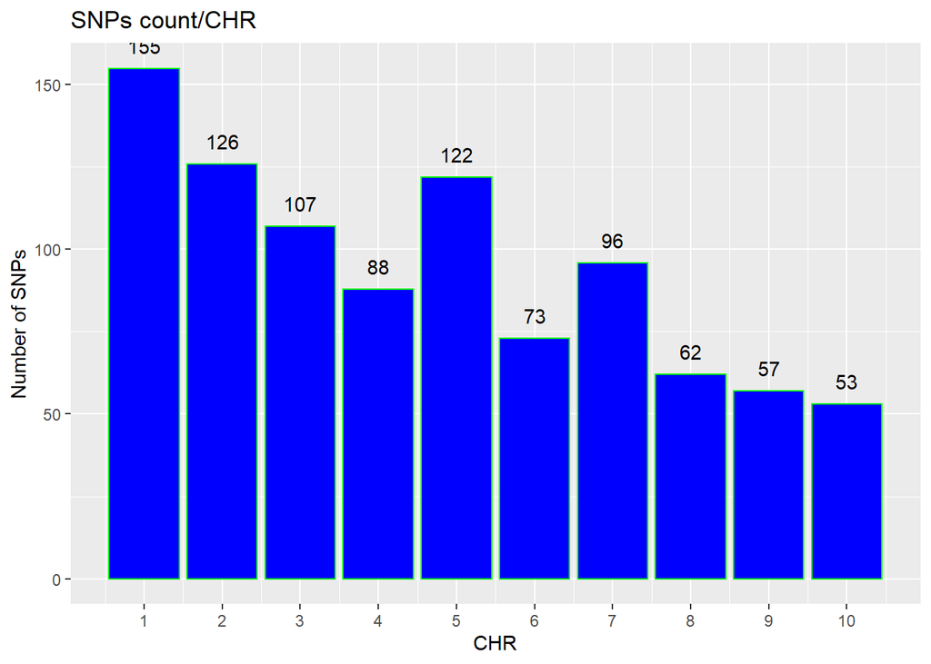

###1b. Plotting SNP distribution across the chromosome _All Here 1. filter the position for anything less than inf and map them to position/1000000, which is in double class 2. Pipe this to create histogram SNP distribution in a chromosome and fill the histogram with green color 3. Use facet Wrap to plot each chromosome 4. Give the X-axis and the y-axis a label

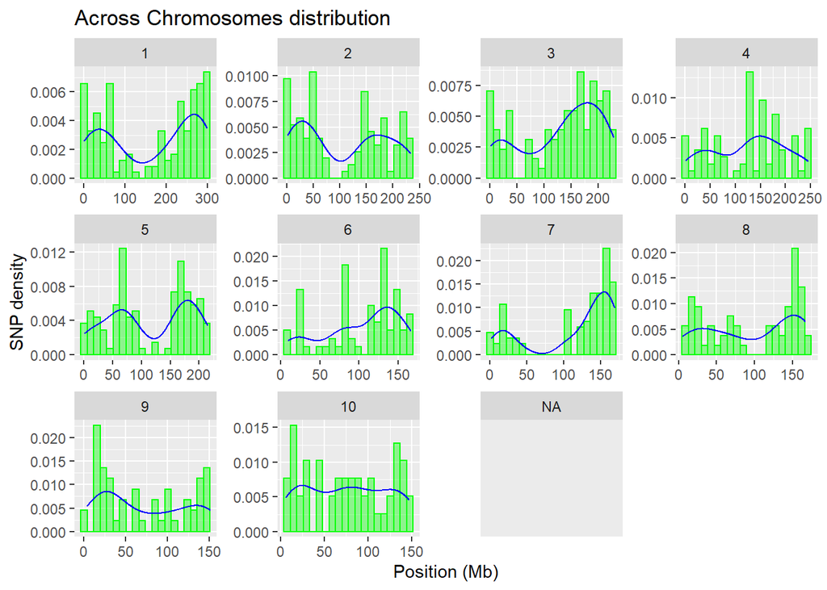

##2.Missing data and amount of heterozygosity

###2a. Proportion of homozygous and Hets by sample #

1. Remove the 2nd tha the 3rd column in fang_et_al and pipe it pivot_long by Sample_ID, to create a tibble of each SNP and its genotypic value
2. Mutate the file to add a colum with Homozygous and hetrozygous SNPs defined

###Plotting by Sample

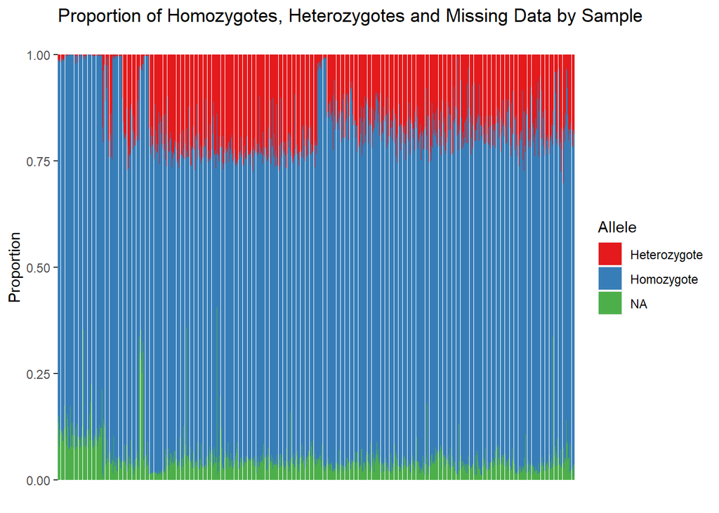

##2b. Proportion of homozygous and Hets by Group # 1. Remove the 1st and the 2nd column in fang_et_al and pipe it to pivot_long by Group, to create a tibble of each group and its genotypic value 2. Mutate the file to add a column with Homozygous and Hetrozygous SNPs defined

###Plot by group

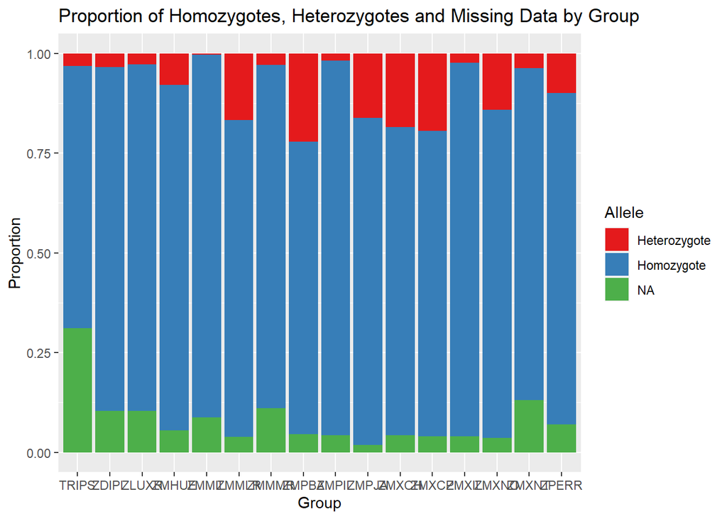

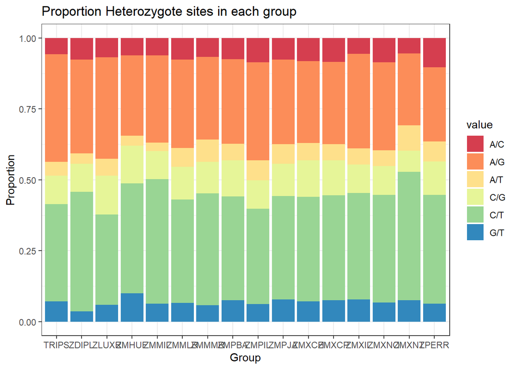